# Project : Intro to Machine Learning - Enron dataset

1. **Summarize for us the goal of this project and how machine learning is useful in trying to accomplish it. As part of your answer, give some background on the dataset and how it can be used to answer the project question. Were there any outliers in the data when you got it, and how did you handle those? [relevant rubric items: “data exploration”, “outlier investigation”]**

The Enron case was one of the biggest financial scandals of the past 20 years. Founded in 1985 by Kenneth Lay, later joined by Jeffrey Skilling, Enron had become, in terms of market capitalization, the 7th US company. In december 2001, Enron went to bankruptcy and disintegrated almost overnight as a result of massive fraudulent brokerages over years.

The present analysis aims at defining a machine learning algorithm to identify the POI (Persons of Interest) based on a number of data such as financial records or mail exchanges derived from the Enron corpus. The idea is to find the correct features and machine learning model with adapted tunining to identify a POI.

The data exploration is performed on the *data_exploration.py* script.

First I checked the shape of the dataset. The initial dataset contains **145 people** with **18 identified as POI** described by **21 features**. Then I converted all the columns in numeric format (email adresses became NaN but we won't use it). Finally I replaced all NaN by zeros.

I checked the number of null values per rows and per columns.

- The **THE TRAVEL AGENCY IN THE PARK** row is not relevant for the analysis and should be removed.
- The **LOCKHART EUGENE E** row is empty and should be removed.
- The column **'loan_advances'** is nearly empty. This feature won't be used.

There is a significant amount of missing values from each feature in this dataset as we can see on the graph below.

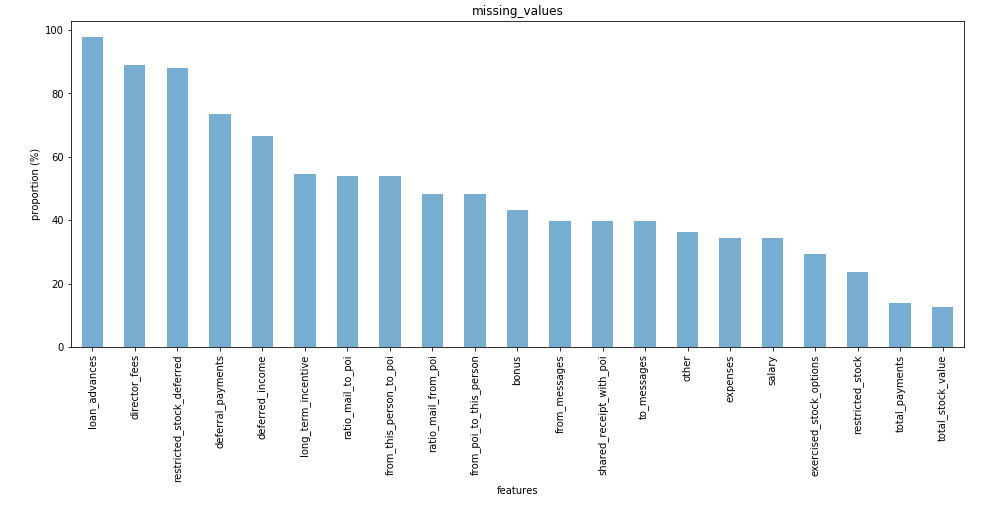

By checking the data graphicaly we can notice that the **TOTAL** row is an outlier in the dataset and should be removed (this outlier has already been highlighted during Udacity course).

I plotted the correlaction matrix of the dataset (this had to be done after removing the TOTAL row). High Pearson's "r" on features not linked (a priori) can indicate the presence of outliers. High Pearson's "r" were obtained between the following features:

- **total stock value vs exercised stock options**: in that case, no outliers apperead, the linear correlation is graphically quite obvious.
- **total payments vs loan advances**: this time, there is one outlier, but as this point corresponds to Kenneth Lay (our main POI so to say), we want to keep him in the dataset.
- **to messages vs shared receipt with poi**: surprisingly, their seems to be a slight lienar correlation between these two features. No significant outliers are to be removed.

I also made a function to search for outliers by calculating the Z-score of all non null data for each column. The function returned all not POI Z-scores above 3.27 or below -3.27 corresponding to $\alpha$ = 0.001 of the population on a two-tailed test. The following outliers are identified:

| Name | Feature | Z-score |
| --- | --- | --- |
| LAVORATO JOHN J | Bonus | Z = 4.74 |
| LAVORATO JOHN J | from_poi_to_this_person | Z = 5.09 |
| FREVERT MARK A | deferral_payments | Z = 4.39 |
| FREVERT MARK A | other | Z = 5.01 |
| FREVERT MARK A | salary | Z = 4.41 |
| KAMINSKI WINCENTY J | from_messages | Z = 7.52 |
| MARTIN AMANDA K | long_term_incentive | Z = 5.14 |
| WHITE JR THOMAS E | restricted_stock | Z = 5.67 |
| BHATNAGAR SANJAY | restricted_stock_deferred | Z = 3.98 |
| SHAPIRO RICHARD S | to_messages | Z = 5.09 |

These outliers should be removed. In order to validate this choice, I ran the algorithm with and without these last outliers. The performances were better without them.

Note: The scatter plots and the correlation matrix are available in the *graph* folder.

1. **What features did you end up using in your POI identifier, and what selection process did you use to pick them? Did you have to do any scaling? Why or why not? As part of the assignment, you should attempt to engineer your own feature that does not come ready-made in the dataset -- explain what feature you tried to make, and the rationale behind it. (You do not necessarily have to use it in the final analysis, only engineer and test it.) In your feature selection step, if you used an algorithm like a decision tree, please also give the feature importances of the features that you use, and if you used an automated feature selection function like SelectKBest, please report the feature scores and reasons for your choice of parameter values. [relevant rubric items: “create new features”, “intelligently select features”, “properly scale features”]**

##### **Additional features:**

The number of mail as itself may not be the best representative feature for identifying a POI (the total number of mails may depend also of the hierarchical position of the person). But, we can assume that POI would communicate betwen themselves at a higher rate than other employees. Therefore, it can be interesting to create ratios of messages to (or from) POI on the total number of to (or from) messages. So I added two features :

- the ratio : mail from_poi_to_this_person / from_messages
- the ratio : mail from_this_person_to_poi / to_messages

The performance of the reatined model has been assessed with and without these new features:

| Evaluation metric | Model with initial features | Model with added features |
| --- | --- | --- |
| Accuracy | 0.859 | 0.860 |
| Precision | 0.513 | 0.511 |
| Recall | 0.432 | 0.433 |
| f1 | 0.469 | 0.470 |

There is almost no difference between the model with and without these new features. This is confirmed in the paragraph below as only one of these 2 added features is used by the select K best function and with the lowest importance.

##### **Features selection:**

In order to pick-up the best features programmaticaly, I used the *SelectKbest* function which select the k most relevant features depending on the chosen algorithm. The algorithm that I retained was the Gaussian Naive Bayes. The following table gives the K best selected features using the *selectKbest* as well as their respective importance.

[output not shown]

##### **Scaling:**

Scaling is important when using a distance based algorithm. For the different tested algorithms, I used a Standard Scaler (based on Z-scores) when relevant. I also tested the effects of a PCA pre-processing on the different algorithm. As the PCA looks for the maximum variance to determine eigen vectors, and the variance is high for high magnitude features, the scaler was usefull in addition to the PCA. However, as I retained the Gaussian Naive Bayes algorithm (which is not distance based) and without PCA, the scaling had no beneficial effect. In fact the PCA decreased the performance of the algorithm.

In the end the best way I found to select the correct parameters like Scaling and PCA was to run the algorithm with and without, and compare the results.

1. **What algorithm did you end up using? What other one(s) did you try? How did model performance differ between algorithms? [relevant rubric item: “pick an algorithm”]**

In general, as we want to perform a classification analysis, a classifier or clustering model may be more adapted than a regression model.

The algorithm I retained in the end is the Gaussian Naive Bayes which gave the best results. I also tried a decision tree algorithm, a K-means algorithm and an AdaBoost algorithm. The performance assessments gave the following results (models tuned with GridSearchCV and StratifiedShuffleSplit with 10 folds to decrease the run time).

| Model | Pipeline | K features | Accuracy | Precision | Recall | Train time (s) |
| --- | --- | --- | --- | --- | --- | --- |
| GaussianNB | no PCA, no Scaler | 10 | 0.86 | 0.51 | 0.43 | 1.21 |
| Decision Tree | PCA, Scaler | 20 | 0.83 | 0.40 | 0.38 | 93.09 |
| AdaBoost | no PCA, no Scaler | 15 | 0.84 | 0.42 | 0.32 | 7.19 |
| K-means | PCA, Scaler | 5 | 0.71 | 0.19 | 0.30 | 51.06 |

The Gaussian Naive Bayes has the best performance and also the best train time. An advantage of Gaussian Naive Bayes is that it is performant on small size training dataset. As our dataset contains a small number of rows, it is not too surprising that the Gaussian Naive Bayes give the best results.

The decision tree precision score was acceptable, but the recall scores were sometimes lower than 0.3 (depending ot the tuning). I tried to set the GridSearchCV scoring to 'recall'. This way, the classifier parameters are taken to maximize the recall. As a result, the recall score slightly increased but at the expense of precision. By doing so, the global performances of this algorithms with recall based scoring or default scoring were equivalent.

The AdaBoost classifier had correct performances but still lower than Gaussian Naive Bayes on our case.

The K-means clustering shows low performances. By eyes only, it is difficult to identify clusters or local optimums in our dataset. This clustering algorithms may not be well adapted to this dataset.

1. **What does it mean to tune the parameters of an algorithm, and what can happen if you don’t do this well? How did you tune the parameters of your particular algorithm? What parameters did you tune? (Some algorithms do not have parameters that you need to tune -- if this is the case for the one you picked, identify and briefly explain how you would have done it for the model that was not your final choice or a different model that does utilize parameter tuning, e.g. a decision tree classifier). [relevant rubric items: “discuss parameter tuning”, “tune the algorithm”]**

Each algorithm comes with a number of parameters. Each parameter can have an influence on the accuracy, precision or recall of the algorithm. By changing the default values of a paremeter, the algorithm can increase (or decrease) its efficiency.

In order to tune the chosen algorithm programmaticaly, I used the grid search cross validation to search for the optimal parameters for each algorithm.

For the Gaussian Naive Bayes which I retained, the parameters are:

- *priors:* Prior probabilities of the classes. If specified the priors are not adjusted according to the data.
- *var_smoothing:* Portion of the largest variance of all features that is added to variances for calculation stability.

For this specific algorithm, these parameters are better let to their default value. However, when testing the decision tree algorithm, a lot of interesting parameters had an influence on the algorithm efficiency. The following table lists these parameters and their selected values in the GridSearchCV:

| Parameter | Description | Value in the parameters grid | Value retained by GridSearchCV |
| --- | --- | --- | --- |
| min_samples_split | minimum number of samples required to do a split | [2, 4, 6, 8, 10] | 2 |
| dtree__criterion | function to measure the quality of a split | ["gini", "entropy"] | gini |
| dtree__random_state | random number generator | [0,40] | 0 |

The tuning of the algorithm has a significant influence on the algorithm efficiency. However, the main factor remains the quality and quantity of data rather than a perfectly tuned algorithm.

1. **What is validation, and what’s a classic mistake you can make if you do it wrong? How did you validate your analysis? [relevant rubric items: “discuss validation”, “validation strategy”]**

The validation of an algorithm consists in running it on a test set and compare the predictions made to the test labels. To do that, we have to split the dataset in two sets, one for training and one for testing.

One classical mistake that can occur is the overfitting. If the data split produces a train set too different from the test set, the algorithm can be "too well adapted" to the train set and therefore, fails to generalized the predictions from the test set. This overfitting generates high variance.  
On the other and, if the algorithm is "too well adapted" to the train set, it may be underfitted and generates high biais.

To balance the biais-variance trade-off, I used a cross validation function which generates folds (train and test splits) randomly. I used the function StratifiedShuffleSplit which is adapted to small size datasets. The advantage of this function is to preserve the percentage of samples for each class. In other words, this function ensures that the number of POI in each test and train set is preserved along all iterations.

I set the number of folds to 100 to ensure a low probability to select several identical folds while keeping an acceptable run time.

1. **Give at least 2 evaluation metrics and your average performance for each of them. Explain an interpretation of your metrics that says something human-understandable about your algorithm’s performance. [relevant rubric item: “usage of evaluation metrics”]**

The performance of the algorithm has been evaluated using accuracy, precision and recall evaluation metrics.

- **accuracy**: How many predictions have been made correctly ? Accuracy can be expressed as the ratio between correclty predicted items and total items.
- **precision**: Of all persons that have been labeled as POI by our algorithm, how many are actually POIs ? Precision can be expressed as the ratio between true positives and the sum of true positive and false positive.
- **recall**: Of all persons that are actualy POIs, how many did our algorithm labeled as POIs ? Recall can be expressed as the ratio between true positives and the sum of true positive and false negative.
- **f1**: Harmonic mean of recall and precision. It can be expressed by the twice the preduct of precision and recall divided by the sum of precision and recall. It gives a global rating of the algorithm taking into account both precision and recall.

After testing the algorithm with the *test_classifier* function *tester.py* script, the results are the following:

| Evaluation metric | Value |
| --- | --- |
| Accuracy | 0.86 |
| Precision | 0.51 |
| Recall | 0.43 |
| f1 | 0.47 |

The precision and recall are both above 0.3 as requested by the project specification. The meaning of these metrics can be summarized as:

- 86% of the predictions have been made correclty.
- 51% of the person labeled POI by our algorithm are actually POIs
- 43% of the actual POIs have been labeled POIs by our algorithm.

### References

- https://en.wikipedia.org/wiki/Enron
- https://pandas.pydata.org/pandas-docs/stable/reference/api/pandas.to_numeric.html
- https://medium.com/greyatom/why-how-and-when-to-scale-your-features-4b30ab09db5e
- https://scikit-learn.org/stable/modules/generated/sklearn.preprocessing.StandardScaler.html
- https://scikit-learn.org/stable/modules/generated/sklearn.feature_selection.SelectKBest.html
- https://scikit-learn.org/stable/modules/generated/sklearn.model_selection.GridSearchCV.html
- https://scikit-learn.org/stable/modules/generated/sklearn.decomposition.PCA.html
- https://scikit-learn.org/stable/modules/generated/sklearn.pipeline.Pipeline.html
- https://scikit-learn.org/stable/modules/generated/sklearn.model_selection.StratifiedShuffleSplit.html
- https://scikit-learn.org/stable/modules/generated/sklearn.naive_bayes.GaussianNB.html
- https://en.wikipedia.org/wiki/Naive_Bayes_classifier
- https://scikit-learn.org/stable/modules/generated/sklearn.tree.DecisionTreeClassifier.html
- https://scikit-learn.org/stable/modules/generated/sklearn.cluster.KMeans.html
- https://scikit-learn.org/stable/modules/generated/sklearn.ensemble.AdaBoostClassifier.html
- https://en.wikipedia.org/wiki/Precision_and_recall